# Supervised Learning - Classification Task

The dataset used in this project is simulated (and can be found here: https://www.kaggle.com/datasets/sonalshinde123/human-decision-fatigue-behavioral-dataset) to approximate plausible behavioral dynamics associated with decision fatigue. Due to the synthetic nature of the data, this project should be interpreted as a **methodological case study** on behavioral ML modeling for classification tasks, focusing on class imbalance and correlated predictors management, interpretabilty, and leakage awareness, rather than as a definitive predictive model of real-world decision fatigue.

# Importing dataset and usefull packages

```python
#import necessary libraries
import pandas as pd
import matplotlib.pyplot as plt
import seaborn as sns
from sklearn.compose import ColumnTransformer
from sklearn.preprocessing import StandardScaler, OneHotEncoder
from sklearn.model_selection import train_test_split
from sklearn.metrics import classification_report
from sklearn.metrics import ConfusionMatrixDisplay
from sklearn.pipeline import Pipeline
from sklearn.linear_model import LogisticRegression
from sklearn.model_selection import cross_val_score
from sklearn.ensemble import RandomForestClassifier


df = pd.read_csv("/content/drive/MyDrive/Test_ML/DecisionFatigue/human_decision_fatigue_dataset.csv")
```

# Exploratory Data Analysis

An in-depth exploratory data analysis (EDA) is performed belove. The purpose of the EDA is to gain an overview and a deeper understanding of the data, identify potential issues (e.g., errors, missing values, duplicates), and determine which algorithms are most suitable for the dataset.

```python
df.head(10)
```

|  | Hours_Awake | Decisions_Made | Task_Switches | Avg_Decision_Time_sec | Sleep_Hours_Last_Night | Time_of_Day | Caffeine_Intake_Cups | Stress_Level_1_10 | Error_Rate | Cognitive_Load_Score | Decision_Fatigue_Score | Fatigue_Level | System_Recommendation |
| --- | --- | --- | --- | --- | --- | --- | --- | --- | --- | --- | --- | --- | --- |
| 0 | 7 | 28 | 7 | 2.30 | 5.8 | Evening | 0 | 2.4 | 0.000 | 2.6 | 15.6 | Low | Continue |
| 1 | 15 | 77 | 22 | 3.65 | 4.5 | Afternoon | 3 | 1.9 | 0.143 | 4.5 | 97.3 | High | Take Break |
| 2 | 11 | 57 | 23 | 3.67 | 6.8 | Night | 2 | 2.1 | 0.000 | 4.1 | 55.4 | Moderate | Slow Down |
| 3 | 8 | 39 | 10 | 2.39 | 5.3 | Afternoon | 1 | 1.0 | 0.000 | 2.3 | 29.7 | Low | Continue |
| 4 | 7 | 46 | 16 | 3.05 | 8.2 | Night | 1 | 2.8 | 0.000 | 3.9 | 19.1 | Low | Continue |
| 5 | 11 | 43 | 17 | 3.04 | 7.2 | Afternoon | 1 | 3.1 | 0.000 | 4.0 | 40.9 | Moderate | Slow Down |
| 6 | 11 | 57 | 19 | 4.31 | 6.2 | Evening | 2 | 1.0 | 0.000 | 3.3 | 54.2 | Moderate | Slow Down |
| 7 | 4 | 18 | 3 | 1.73 | 6.8 | Afternoon | 1 | 1.4 | 0.000 | 1.5 | 0.0 | Low | Continue |
| 8 | 8 | 35 | 8 | 0.79 | 6.0 | Night | 2 | 4.3 | 0.000 | 4.0 | 18.8 | Low | Continue |
| 9 | 3 | 9 | 2 | 1.11 | 8.0 | Night | 2 | 2.7 | 0.000 | 2.0 | 0.0 | Low | Continue |

```python
df.info()
```

```
<class 'pandas.core.frame.DataFrame'>
RangeIndex: 25000 entries, 0 to 24999
Data columns (total 13 columns):
 #   Column                  Non-Null Count  Dtype
---  ------                  --------------  -----
 0   Hours_Awake             25000 non-null  int64
 1   Decisions_Made          25000 non-null  int64
 2   Task_Switches           25000 non-null  int64
 3   Avg_Decision_Time_sec   25000 non-null  float64
 4   Sleep_Hours_Last_Night  25000 non-null  float64
 5   Time_of_Day             25000 non-null  object
 6   Caffeine_Intake_Cups    25000 non-null  int64
 7   Stress_Level_1_10       25000 non-null  float64
 8   Error_Rate              25000 non-null  float64
 9   Cognitive_Load_Score    25000 non-null  float64
 10  Decision_Fatigue_Score  25000 non-null  float64
 11  Fatigue_Level           25000 non-null  object
 12  System_Recommendation   25000 non-null  object
dtypes: float64(6), int64(4), object(3)
memory usage: 2.5+ MB
```

Using the attribute .info it can be seen that the dataset consists of 13 columns and 25000 rows. There appear to be no missing values (but it should be checked whether they could have been encoded in other ways). The encoding of the data type within each column appears to be consistent with the information represented in the column (e.g., there are no numeric columns encoded as strings). Unfortunately the simulated dataset is accompied by very little metadata. Metata would be really usefull for having usefull contextual information about data that could drive decisions during the modelling phase. For example, it is not really clear when and how some variables have been measured (e.g. Cognitive_Load)

```python
df.describe(include = "all")
```

|  | Hours_Awake | Decisions_Made | Task_Switches | Avg_Decision_Time_sec | Sleep_Hours_Last_Night | Time_of_Day | Caffeine_Intake_Cups | Stress_Level_1_10 | Error_Rate | Cognitive_Load_Score | Decision_Fatigue_Score | Fatigue_Level | System_Recommendation |
| --- | --- | --- | --- | --- | --- | --- | --- | --- | --- | --- | --- | --- | --- |
| count | 25000.000000 | 25000.000000 | 25000.000000 | 25000.000000 | 25000.000000 | 25000 | 25000.000000 | 25000.000000 | 25000.000000 | 25000.000000 | 25000.000000 | 25000 | 25000 |
| unique | NaN | NaN | NaN | NaN | NaN | 4 | NaN | NaN | NaN | NaN | NaN | 3 | 3 |
| top | NaN | NaN | NaN | NaN | NaN | Afternoon | NaN | NaN | NaN | NaN | NaN | Low | Continue |
| freq | NaN | NaN | NaN | NaN | NaN | 8827 | NaN | NaN | NaN | NaN | NaN | 11729 | 11728 |
| mean | 9.088280 | 45.433080 | 13.623480 | 2.918346 | 6.085956 | NaN | 1.897240 | 2.202736 | 0.031877 | 3.365784 | 40.579280 | NaN | NaN |
| std | 4.928093 | 25.611583 | 8.521595 | 0.942644 | 1.114586 | NaN | 1.430483 | 1.329868 | 0.057457 | 1.729092 | 36.704221 | NaN | NaN |
| min | 1.000000 | 0.000000 | 0.000000 | 0.500000 | 2.000000 | NaN | 0.000000 | 1.000000 | 0.000000 | 0.600000 | 0.000000 | NaN | NaN |
| 25% | 5.000000 | 23.000000 | 7.000000 | 2.270000 | 5.300000 | NaN | 1.000000 | 1.000000 | 0.000000 | 1.900000 | 0.000000 | NaN | NaN |
| 50% | 9.000000 | 45.000000 | 13.000000 | 2.910000 | 6.100000 | NaN | 2.000000 | 1.800000 | 0.000000 | 3.200000 | 34.650000 | NaN | NaN |
| 75% | 13.000000 | 67.000000 | 20.000000 | 3.550000 | 6.900000 | NaN | 3.000000 | 3.100000 | 0.045000 | 4.600000 | 74.200000 | NaN | NaN |
| max | 17.000000 | 117.000000 | 48.000000 | 6.800000 | 9.000000 | NaN | 6.000000 | 8.700000 | 0.359000 | 9.700000 | 100.000000 | NaN | NaN |

## Visualize columns distributions

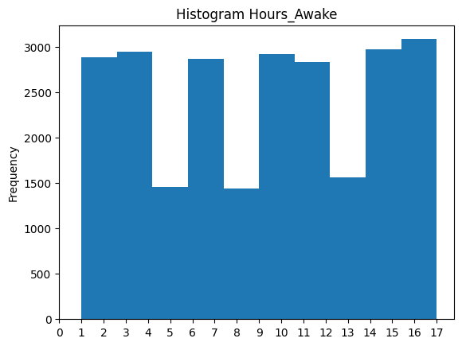

```python
df["Hours_Awake"].plot(kind = "hist")
plt.title("Histogram Hours_Awake")
plt.xticks([i for i in range(18)])
plt.show()
```

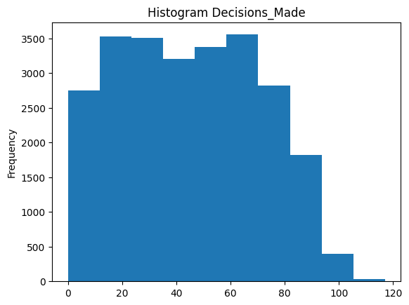

```python
df["Decisions_Made"].plot(kind = "hist")
plt.title("Histogram Decisions_Made")
plt.show()
```

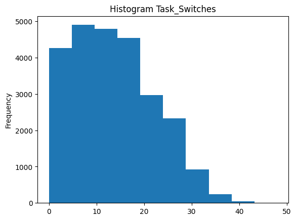

```python
df["Task_Switches"].plot(kind = "hist")
plt.title("Histogram Task_Switches")
plt.show()
```

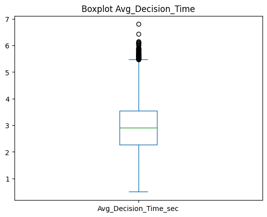

```python
df["Avg_Decision_Time_sec"].plot(kind = "box")
plt.title("Boxplot Avg_Decision_Time")
plt.show()
```

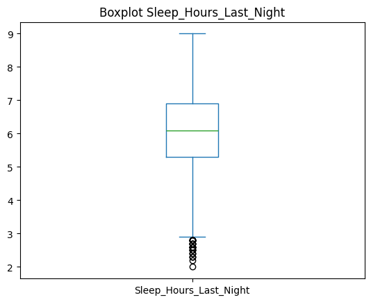

```python
df["Sleep_Hours_Last_Night"].plot(kind = "box")
plt.title("Boxplot Sleep_Hours_Last_Night")
plt.show()
```

```
  Time_of_Day  count
0   Afternoon   8827
1     Evening   6299
2     Morning   6044
3       Night   3830
------------------------------------------------------------------------------------------------------------------------
```

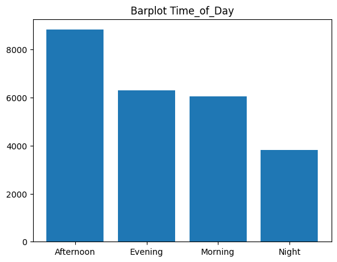

```python
Time_of_Day = df["Time_of_Day"].value_counts().reset_index()
print(Time_of_Day)
print("----"*30)
plt.bar(x = Time_of_Day["Time_of_Day"], height = Time_of_Day["count"])
plt.title("Barplot Time_of_Day")
plt.show()
```

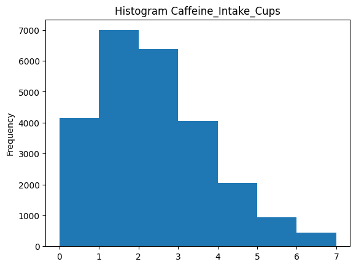

```python
df["Caffeine_Intake_Cups"].plot(
    kind="hist",
    bins=range(df["Caffeine_Intake_Cups"].min(),
               df["Caffeine_Intake_Cups"].max() + 2)
)
plt.title("Histogram Caffeine_Intake_Cups")
plt.show()
```

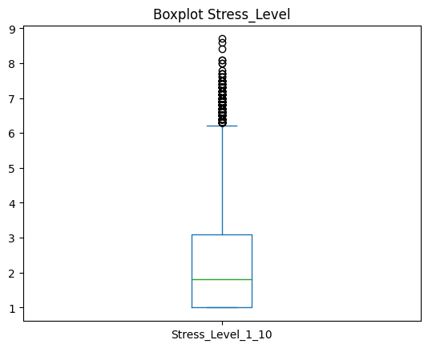

```python
df["Stress_Level_1_10"].plot(kind = "box")
plt.title("Boxplot Stress_Level")
plt.show()
```

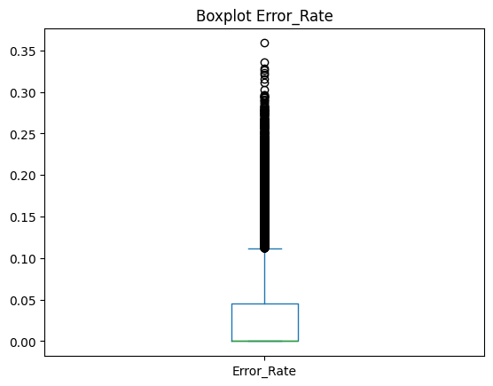

```python
df["Error_Rate"].plot(kind = "box")
plt.title("Boxplot Error_Rate")
plt.show()
```

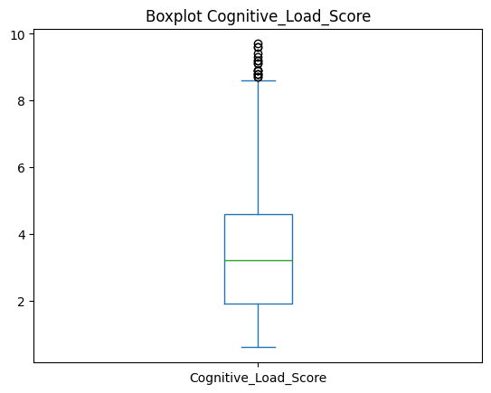

```python
df["Cognitive_Load_Score"].plot(kind = "box")
plt.title("Boxplot Cognitive_Load_Score")
plt.show()
```

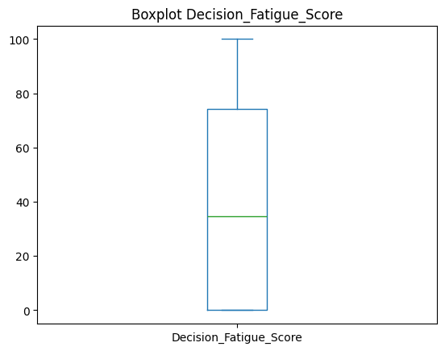

```python
df["Decision_Fatigue_Score"].plot(kind = "box")
plt.title("Boxplot Decision_Fatigue_Score")
plt.show()
```

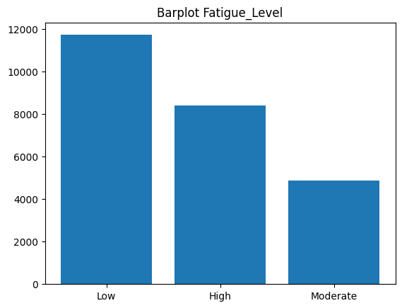

```python
Fatigue_Lvl = df["Fatigue_Level"].value_counts().reset_index()
plt.bar(x = Fatigue_Lvl["Fatigue_Level"], height = Fatigue_Lvl["count"])
plt.title("Barplot Fatigue_Level")
plt.show()
```

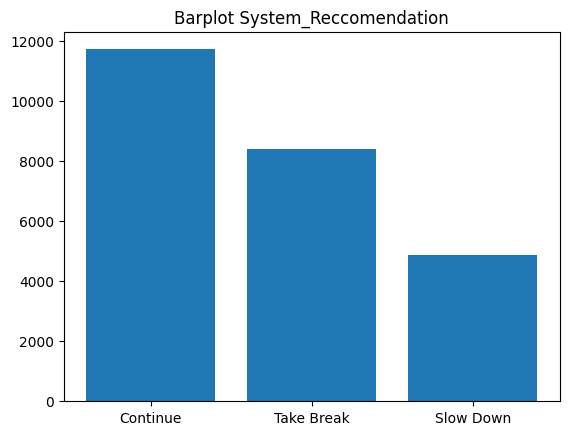

```python
System_Rec = df["System_Recommendation"].value_counts().reset_index()
plt.bar(x = System_Rec["System_Recommendation"], height = System_Rec["count"])
plt.title("Barplot System_Reccomendation")
plt.show()
```

From this first EDA part, it can be observed that the values in the dataset are consistent with the meaning of the corresponding columns. In particular, for those features where a valid range of values is defined, all observations fall within the expected range and no obvious outliers or impossible values are detected. Moreover, no missing values — including potential hidden missing values (e.g., values encoded as 0 or 99) — are observed, although the lack of metadata makes this assessment more challenging.

Regarding the target variable (Fatigue Level), a clear class imbalance is present. Specifically, the Low fatigue level is much more represented than the Moderate level, while the High level lies in between. This imbalance should be taken into account during the model implementation phase. Moreover, it can be seen that the target variable is a variable with three classes, this means that the classifiacation task will be a multi-class classification. Additionaly, it should be pointed out how the variable is not a simple nominal variable but an ordinal one, indeed the three classes have a semantic/logical order Low>Medium>High

## Visualizations Features vs Target

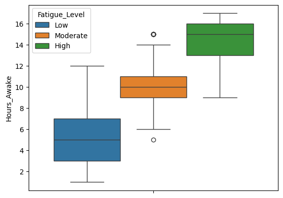

```python
sns.boxplot( data=df,
    y="Hours_Awake",
    hue="Fatigue_Level",
    hue_order = ["Low", "Moderate", "High"]
)
```

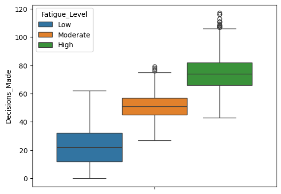

```python
sns.boxplot(data = df,
            y = "Decisions_Made",
            hue = "Fatigue_Level",
            hue_order = ["Low", "Moderate", "High"])
```

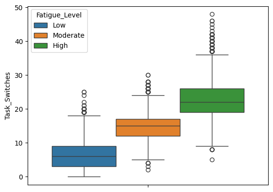

```python
sns.boxplot(data = df,
            y="Task_Switches",
            hue = "Fatigue_Level",
            hue_order = ["Low", "Moderate", "High"])
```

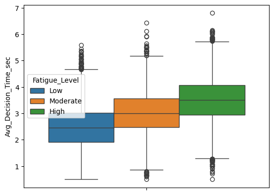

```python
sns.boxplot(data = df,
            y = "Avg_Decision_Time_sec",
            hue = "Fatigue_Level",
            hue_order = ["Low", "Moderate", "High"])
```

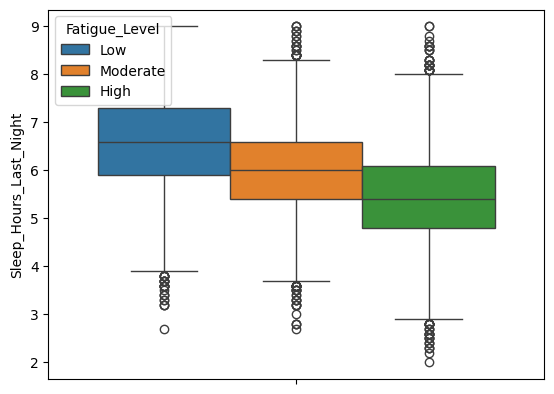

```python
sns.boxplot(data = df,
            y = "Sleep_Hours_Last_Night",
            hue = "Fatigue_Level",
            hue_order = ["Low", "Moderate", "High"])
```

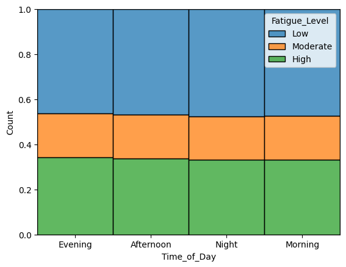

```python
sns.histplot(
    data=df,
    x="Time_of_Day",
    hue="Fatigue_Level",
    hue_order = ["Low", "Moderate", "High"],
    multiple="fill"
)

#we use relative frequencies in this plot, beacuse we have already see that there is imbalance among classes of the feature Time_of_Day
```

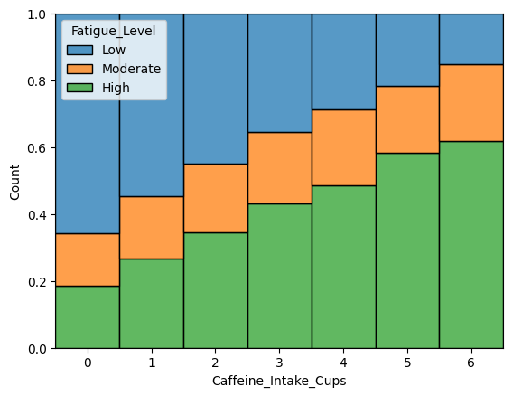

```python
sns.histplot(
    data=df,
    x="Caffeine_Intake_Cups",
    hue="Fatigue_Level",
    hue_order = ["Low", "Moderate", "High"],
    multiple="fill",
    discrete=True
) #in this case we use a histogram beacuse Caffeine_Intake_Cups is a discret vaiable with few values (range from 0 to 6)
```

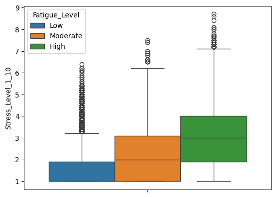

```python
sns.boxplot(data = df,
            y = "Stress_Level_1_10",
            hue = "Fatigue_Level",
            hue_order = ["Low", "Moderate", "High"])
```

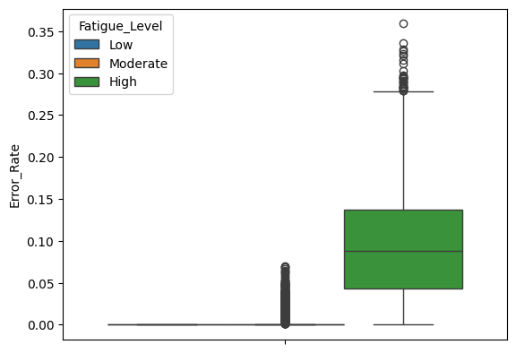

```python
sns.boxplot(data = df,
            y = "Error_Rate",
            hue = "Fatigue_Level",
            hue_order = ["Low", "Moderate", "High"])
```

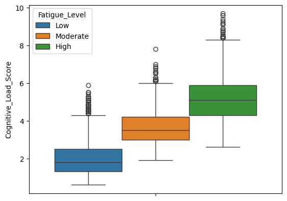

```python
sns.boxplot(data = df,
            y = "Cognitive_Load_Score",
            hue = "Fatigue_Level",
            hue_order = ["Low", "Moderate", "High"])
```

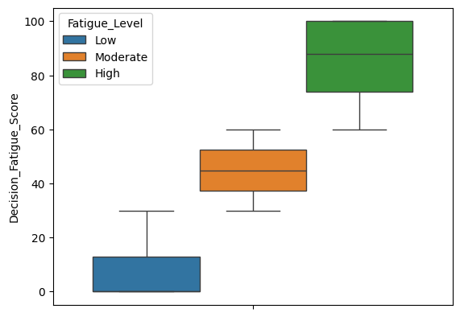

```python
sns.boxplot(data = df,
            y = "Decision_Fatigue_Score",
            hue = "Fatigue_Level",
            hue_order = ["Low", "Moderate", "High"])
```

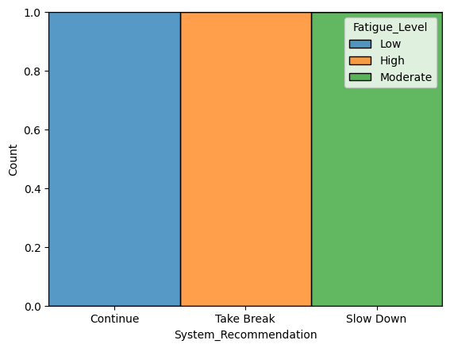

```python
sns.histplot(
    data=df,
    x="System_Recommendation",
    hue="Fatigue_Level",
    multiple="fill"
)
```

## Correlations

```python
#selezioniamo le colonne numeriche
num_cols = df.select_dtypes(include="number").columns
num_cols = num_cols.drop("Decision_Fatigue_Score") #eliminiamo la feature che non useremmo sicuramente
corr_mat = df[num_cols].corr(method="spearman") # we use spearman correlation since it does not assume linear relationships
```

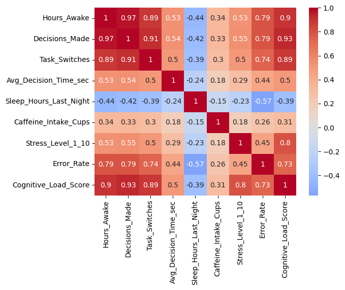

```python
sns.heatmap(
    corr_mat,
    cmap="coolwarm",
    center=0,
    annot=True
)
```

```python
#check for duplicated rows
print(any(df.duplicated()))
print(len(df.loc[df.duplicated,:])) #only one row is duplicated
df.drop_duplicates(keep='first', inplace=True) #remove the duplicated row
print(any(df.duplicated()))
```

```
True
1
False
```

Comments on EDA:

- Many features in the dataset separate the three classes of the Fatigue Level (our target variable) quite well (e.g., Hours_Awake, Decisions_Made, Task_Switches).
- For several features, we observe a monotonic relationship with the target variable, which is coherent with their semantic meaning. For instance, Hours_Awake shows a positive monotonic relationship with Fatigue Level (higher Hours_Awake → higher Fatigue Level), whereas Hours_Sleep_Last_Night exhibits a negative monotonic relationship (higher Hours_Sleep_Last_Night → lower Fatigue Level).
- Some features should definitely be removed to avoid data leakage (namely System_Recommendation and Decision_Fatigue_Score), as the plots clearly indicate that they are deterministic transformations of the target variable.
- One feature (Error_Rate) separate the High Fatigue Level particularly well from the other two classes (Low and Moderate). Despite not beeing a perfect class separation, we do not know how and when Error_Rate and Fatigue_Level are measured: so it is not possible to determine if Fatigue_Level is the cause or the consequence of Error_Rate. Therefore, caution is required when including this feature in the model.
- Lastly, despite plots do not show anything strange, based on domain knowledge, we know that Cognitive_Load and Fatigue_Level are two very similar concepts. Again, the lack of metadata, does not allow us to know how Cognitive_Load and Fatigue_Level are operationalized and measured so, in a similar vein to Error_Rate, also for the Cognitive_Load_Score feature a special care will be taken.
- Several numerical features exhibit high pairwise correlations, indicating a potential risk of multicollinearity.
- A duplicated row was detected in the dataset. Duplicate observations may cause issues if the same record appears both in the training and in test set. Given that only one duplicated row was detected, it was removed.

# Models implementation

## Features Selection

```python
features_names = df.columns.drop(['Decision_Fatigue_Score', 'System_Recommendation', 'Fatigue_Level']) #all the columns are selected except the target column and the two columns that in the EDA
#phase have been identified as a derivation of the target variable

outcome_name = "Fatigue_Level"
```

```python
X = df[features_names]
y = df[outcome_name]
```

## Train test split

```python
X_train, X_test, y_train, y_test = train_test_split(X, y, test_size=0.3, stratify = y, random_state=42) # The target variable was stratified to preserve class distribution in both the training and test sets.
```

# Logistic Regression

The first model implemented is a Logistic Regression with ridge regolarization to manage the potentail risk of multicollinearity detected in the EDA phase. Numeric features will be standardized to allow a comparison of the coefficients, to facilitate model convergence and beacause it is mandatory when using regolarization. To asses the model performance in the training phase a 5-folds cross-validation was implemented.

```python
#divide numeric features and the categorical one
num_feature = [i for i in X_train.columns if i != "Time_of_Day"]
cat_feature = ["Time_of_Day"]
```

```python
#define features scaling and one-hot encoding
preprocess = ColumnTransformer(
    transformers=[
        ("num", StandardScaler(), num_feature),
        ("cat", OneHotEncoder(drop="first"), cat_feature)
    ]
)
```

```python
#define the pipeline to fit the Logistic Regression
baseline_pipeline_log = Pipeline([
    ("preprocess", preprocess),
    ("clf", LogisticRegression(
        solver="lbfgs",
        penalty="l2",
        max_iter=1000
    ))
])
```

```python
#implement cross-validation (in this way we can avoid overfitting)
scores = cross_val_score(
    baseline_pipeline_log,
    X_train, y_train,
    cv=5, #5 folds
    scoring="f1_macro" #f1 because of unbalanced target
)


scores.mean(), scores.std()
```

```
(np.float64(0.9926056491760953), np.float64(0.0009054586161357403))
```

**Comment on the training phase of the Logistic Regression**:

The Logistic Regression implemented reports a mean f1 score of 0.993 with really little varabiability among folds (std_dev: 0.001). The metric used to evaluate the model was f1 instead of accuracy because of class imbalance on the target. Such an high score on the f1 metric will be almost impossible to obtain in a real-world dataset but, as stated at the beginnig of this notebook, the current dataset is a simulated one and the objective of this project is methodological rather than predictive.

## Sanity check

The second model that will be implemented is Random Forest, which different from logistic regression allow to capture also non-linear patterns. However, in the EDA phase, two features (namely Cognitive_Load_Score and Error_Rate) were flagged as potential problematic. To ensure the result obtained with logistic regression is not due to data leakage, a sanity check will be performed belove. In details, it will be tested how the predictive model performance changes when one or both the eventually "problematic" features are not included in the training set.

```python
#function that allow to modify the features in the training set and calculate the f1-score using a crossvalidation
def calcola_f1(features, outcome, columns_to_drop):
  X = features.copy()
  X.drop(columns = columns_to_drop, inplace = True)

  num_features = list(X.select_dtypes(include = "number").columns) #make a list with the names of the remaing columns
  cat_feature = ["Time_of_Day"] #the categorical feature

  preprocess_local = ColumnTransformer(
      transformers=[
          ("num", StandardScaler(), num_features),
          ("cat", OneHotEncoder(drop="first", handle_unknown="ignore"), cat_feature)
      ],
      remainder="drop"
  )

  pipeline_local = Pipeline([
      ("preprocess", preprocess_local),
      ("clf", LogisticRegression(
          solver="lbfgs",
          penalty="l2",
          max_iter=1000
      ))
  ])

  scores_temp = cross_val_score(
    pipeline_local,
    X, outcome,
    cv=5,
    scoring="f1_macro"
)


  return scores_temp.mean(), scores_temp.std() #return mean F1 and std F1 between the 5 folds
```

```python
print("Total F1 mean is:", calcola_f1(X_train, y_train, [])[0])
print("Mean F1 when 'Error_Rate' is removed is:", calcola_f1(X_train, y_train, ["Error_Rate"])[0])
print("Mean F1 when 'Cognitive_Load_Score' is removed is:", calcola_f1(X_train, y_train, ["Cognitive_Load_Score"])[0])
print("Mean F1 when 'Error Rate' and Cognitive_Load_Score' are removed is:", calcola_f1(X_train, y_train, ["Error_Rate", "Cognitive_Load_Score"])[0])
```

```
Total F1 mean is: 0.9926056491760953
Mean F1 when 'Error_Rate' is removed is: 0.9942068086982673
Mean F1 when 'Cognitive_Load_Score' is removed is: 0.9926528698831752
Mean F1 when 'Error Rate' and Cognitive_Load_Score' are removed is: 0.9941336144471784
```

Comparing the F1 of the different models it can be seen that it remains similar also eliminating the features Error_Rate and Cognitive_Load_Score. From this analysis, it can be concluded that the two features do not have a dramatic impact on the result of the model, so they will be kept in the training set also for the Random Forest algorithm.

# Random Forest

```python
#divide numeric features and the categorical one
num_feature_rf = [i for i in X_train.columns if i != "Time_of_Day"]
cat_feature_rf = ["Time_of_Day"]
```

```python
#for the RF we do not need to standardize numeric features, but of course we need to One-Hot encoding the categorical one
preprocess_rf = ColumnTransformer(
    transformers=[
        ("num", "passthrough", num_feature_rf),
        ("cat", OneHotEncoder(), cat_feature_rf), #we do not need to drop one level becasue RF does not suffer of prefect collinearity problem
    ]
)
```

```python
rf_pipeline = Pipeline([
    ("preprocess", preprocess_rf),
    ("clf", RandomForestClassifier(
        n_estimators=500, #500 trees
        random_state=42, #random state for reproducibility
    ))
])
```

```python
scores_rf = cross_val_score(
    rf_pipeline,
    X_train, y_train,
    cv=5,
    scoring="f1_macro"
)
scores_rf.mean(), scores_rf.std()
```

```
(np.float64(0.9628664494182008), np.float64(0.0035184085439021397))
```

**Comment on the training phase of the Random Forest**

Random Forest reports a slightly lower f1-score with respect to Logistic Regression. It can be hypothesized that this slightly lower performance was due to the fact that, in simulating the dataset, the target variable was implemented as a linear derivation of the features.

# Predictions

Evaluating the models on the test set.

## Logistic Regression predictions

```python
#using the first model tested
baseline_pipeline_log.fit(X_train, y_train);
```

```python
y_pred_log = baseline_pipeline_log.predict(X_test)
```

```python
#classification report
print(classification_report(y_test, y_pred_log))
```

```
              precision    recall  f1-score   support

        High       1.00      1.00      1.00      2521
         Low       1.00      1.00      1.00      3519
    Moderate       0.99      0.99      0.99      1460

    accuracy                           1.00      7500
   macro avg       0.99      0.99      0.99      7500
weighted avg       1.00      1.00      1.00      7500
```

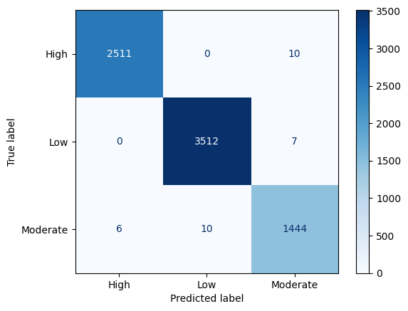

```python
#Confusion Matrix
disp = ConfusionMatrixDisplay.from_estimator(
        baseline_pipeline_log,
        X_test,
        y_test,
        cmap=plt.cm.Blues
    )
#print(disp.confusion_matrix)
plt.grid(False)
plt.show()
```

**Comments on the predictions of Logistic Regression**

In the prediction phase is evaluated the ability of the model to generalize the learn relationship to unseen data. Of course, given the synthetic nature of the dataset, the logistic model achieved a high f1.

The analysis of the confusion matrix shows that although the model treats the target variable as nominal, without explicitly accounting for the inherent ordering of the classes (Low < Medium < High), nevertheless, the misclassifications occur exclusively between adjacent categories. Specifically, some instances of the Moderate class are predicted as either Low or High, while no extreme. In many real-world scenarios, confusing adjacent categories is less problematic than misclassifying observations into opposite extremes.

## Ranfom Forest predictions

```python
rf_pipeline.fit(X_train, y_train) #train the model on all the train data
y_pred_rf = rf_pipeline.predict(X_test) #make predictions on the test set
```

```python
print(classification_report(y_test, y_pred_rf))
```

```
              precision    recall  f1-score   support

        High       0.98      0.99      0.98      2521
         Low       0.99      0.98      0.99      3519
    Moderate       0.94      0.93      0.94      1460

    accuracy                           0.98      7500
   macro avg       0.97      0.97      0.97      7500
weighted avg       0.98      0.98      0.98      7500
```

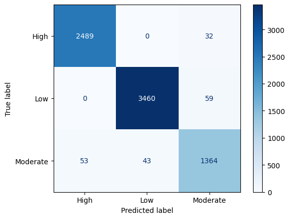

```python
disp = ConfusionMatrixDisplay.from_estimator(
        rf_pipeline,
        X_test,
        y_test,
        cmap=plt.cm.Blues
    )
#print(disp.confusion_matrix)
plt.grid(False)
plt.show()
```

**Comments on the prediction of the Random Forest**

Random Forest model achieved a slightly lower F1-score with respct to the Logistic model. Also for this model, however the confusion matrix shows an error pattern coherent with the semantic meaning of the classes.

# Models interpretation

Logistic Regression and Random Forest differ in terms of interpretability. Indeed, Logistic Regression coefficients provide information about both the magnitude and direction of the relationship between predictors and the outcome. In contrast, Random Forest does not provide directly interpretable parameters. Its interpretation relies on feature importance measures, which indicate the relative contribution of each variable to the model’s predictive performance, but do not provide information about the direction of the effects.

Below logistic regression coefficients and Random Forest features importance will be interpreted.

## Logistic Regression coefficients

```python
clf = baseline_pipeline_log.named_steps["clf"]
feature_names = baseline_pipeline_log.named_steps["preprocess"].get_feature_names_out()

coef_df = pd.DataFrame(
    clf.coef_,
    columns=feature_names,
    index=clf.classes_
)
coef_df
```

|  | num__Hours_Awake | num__Decisions_Made | num__Task_Switches | num__Avg_Decision_Time_sec | num__Sleep_Hours_Last_Night | num__Caffeine_Intake_Cups | num__Stress_Level_1_10 | num__Error_Rate | num__Cognitive_Load_Score | cat__Time_of_Day_Evening | cat__Time_of_Day_Morning | cat__Time_of_Day_Night |
| --- | --- | --- | --- | --- | --- | --- | --- | --- | --- | --- | --- | --- |
| High | 12.115473 | 6.617431 | 5.759692 | 0.091886 | -3.893754 | -1.855856 | -1.562002 | 2.169459 | 3.574996 | 0.037014 | 0.111793 | -0.090637 |
| Low | -12.439250 | -7.091602 | -5.954909 | -0.070061 | 4.270372 | 1.889451 | 1.633144 | -0.705924 | -3.723069 | -0.011076 | -0.129352 | 0.130105 |
| Moderate | 0.323777 | 0.474171 | 0.195217 | -0.021824 | -0.376619 | -0.033595 | -0.071141 | -1.463535 | 0.148073 | -0.025937 | 0.017559 | -0.039468 |

INTERPRETATION OF THE RESULTS:

- In line with EDA, Hours_Awake, Decision_Made and Task_Switches seem to be among the most influential features to discriminate if an observation belongs to High or Low fatigue level. These features are positevily associated with High Fatigue, and negative associated with Low Fatigue. At the opposite Sleep_Hours_Last_Night is the most influential feature positive correlated with Low Fatigue and negative correlated with High Fatigue.
- Differently from High and Low classes, there are not features that are strongly associated with the Moderate class. The most influential one results to be Error_Rate
- Interestingly, despite EDA showed a monotonic positive relationship for the Stress_Level feature and the Fatigue_Level, the model shows an opposite sign for the association between this feature and the target. The effect is probably due to the high correlation between Stress_Level and the Cognitive_Load features.

## Random Forest features importance

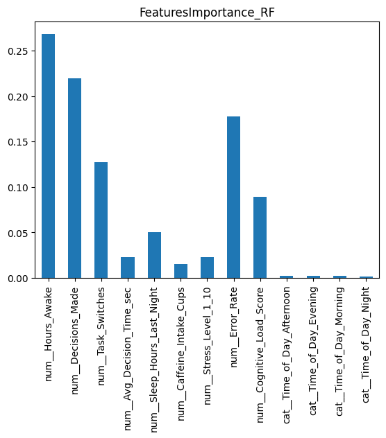

```python
features_importance_rf = pd.Series(rf_pipeline.named_steps["clf"].feature_importances_, index = rf_pipeline.named_steps["preprocess"].get_feature_names_out())
features_importance_rf.plot.bar()
plt.title("FeaturesImportance_RF")
plt.show()
```

INTERPRETATION OF THE RESULTS:

- Feature importance analysis reveals that Hours_Awake, Decision_Made and Error_Rate are the features the model use the most for making predictions, while the moment of the day (Afternoon, Evening, Morning, Night) has a really low impact.

# Conclusion

This project provided a methodological evaluation of supervised classification models applied to a structured simulated dataset related to decision fatigue. The analysis compared a regularized linear classifier (Logistic Regression with L2 penalty) and a non-linear ensemble method (Random Forest), examining their predictive performance, robustness to potentially problematic predictors, and interpretability.

An important limitation of this project is that the target variable represents an ordinal construct (Low, Moderate, High), while the models employed treat it as nominal. Future methodological extensions could include models which explicitly account for the ordered nature of the outcome.